# Əsas Ölçmə Modeli: X = T + E

Klassik Test Nəzəriyyəsinin Fundamental Modeli

Klassik Test Nəzəriyyəsi Kursu

2025-07-17

## 0.1 Dərsin Məqsədləri

✓ Klassik Test Nəzəriyyəsinin əsas modelini dərindən anlamaq  
✓ Həqiqi bal (T) və Xəta (E) komponentlərini izah etmək  
✓ CTT-nin fundamental fərziyyələrini öyrənmək  
✓ R simulyasiyaları ilə modeli praktik tətbiq etmək

## 0.2 Əvvəlki Dərsdən Xatırladıqlarımız

**Dərs 1-də öyrəndiklərimiz:** - Ölçmə nəzəriyyəsinin əsasları - Psixometrik üçlük: Etibarlılıq, Validlik, Praktiklik - X = T + E formulasının giriş səviyyəsi - Test nəzəriyyəsinin tarixi inkişafı

# 1 Klassik Test Nəzəriyyəsinin Əsas Modeli

## 1.1 CTT Modelinin Dərin Analizi

Allen və Yen (2002) kitabının 2-ci fəslinə əsasən, Klassik Test Nəzəriyyəsinin ürəyi **aşağıdakı sadə, lakin güçlü modeldir:**

### 1.1.1 **X = T + E**

Bu formulada: - **X** = Müşahidə olunan bal (Observed Score) - **T** = Həqiqi bal (True Score)  
- **E** = Xəta komponenti (Error Component)

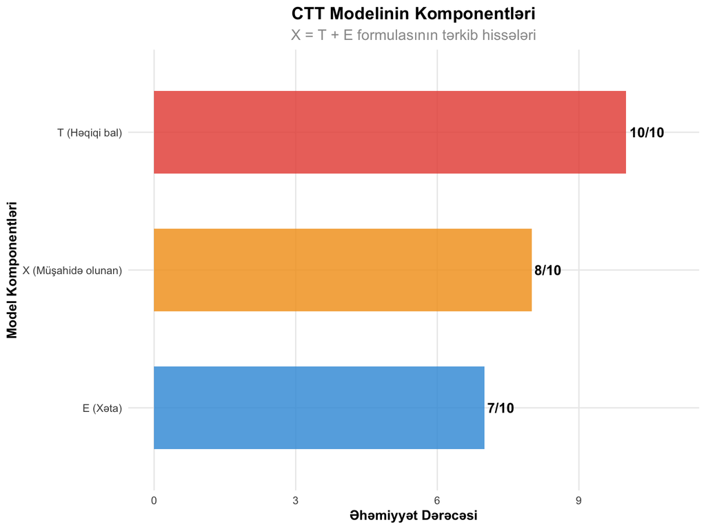

```r
# CTT modelinin komponentlərinin vizual təqdimatı
components <- data.frame(
  Komponent = c("X (Müşahidə olunan)", "T (Həqiqi bal)", "E (Xəta)"),
  Xarakteristika = c("Faktiki test nəticəsi", "Həqiqi qabiliyyət", "Təsadüfi xəta"),
  Nezaret = c("Müşahidə edilir", "Gizli dəyişən", "Təsadüfi"),
  Ehemiyyet = c(8, 10, 7)
)

ggplot(components, aes(x = reorder(Komponent, Ehemiyyet), y = Ehemiyyet, fill = Komponent)) +
  geom_col(alpha = 0.8, width = 0.6) +
  geom_text(aes(label = paste0(Ehemiyyet, "/10")),
            hjust = -0.1, fontface = "bold", size = 4) +
  coord_flip() +
  scale_fill_manual(values = colors_basic[1:3]) +
  labs(title = "CTT Modelinin Komponentləri",
       subtitle = "X = T + E formulasının tərkib hissələri",
       x = "Model Komponentləri", y = "Əhəmiyyət Dərəcəsi") +
  theme_clean() +
  theme(legend.position = "none") +
  ylim(0, 11)
```

```r
kable(components[,-4], caption = "CTT Model Komponentlərinin Xarakteristikaları")
```

CTT Model Komponentlərinin Xarakteristikaları

| Komponent | Xarakteristika | Nezaret |
| --- | --- | --- |
| X (Müşahidə olunan) | Faktiki test nəticəsi | Müşahidə edilir |
| T (Həqiqi bal) | Həqiqi qabiliyyət | Gizli dəyişən |
| E (Xəta) | Təsadüfi xəta | Təsadüfi |

# 2 Həqiqi Bal (True Score) Anlayışı

## 2.1 Həqiqi Balın Təyini

**Allen və Yen (2002, səh. 28)** kitabında həqiqi bal belə təyin edilir:

> **Həqiqi bal** - eyni şəraitdə sonsuz dəfə test aparılsa, alınan balların arifmetik ortasıdır.

### 2.1.1 Həqiqi Balın Xüsusiyyətləri

```r
# Həqiqi balın xüsusiyyətləri
true_score_props <- data.frame(
  Xususiyyet = c("Sabit dəyər", "Fərdi xarakteristika", "Müşahidə olunmaz",
                 "Nəzəri konstrukt", "Xətasız ölçmə"),
  Izah = c("Hər fərd üçün sabit", "Şəxsə xas qabiliyyət", "Birbaşa ölçülə bilməz",
           "Riyazi model", "İdeal şəraitdə ölçmə"),
  Praktik_Ehemiyyet = c(9, 10, 7, 6, 8)
)

kable(true_score_props, caption = "Həqiqi Balın Fundamental Xüsusiyyətləri")
```

Həqiqi Balın Fundamental Xüsusiyyətləri

| Xususiyyet | Izah | Praktik_Ehemiyyet |
| --- | --- | --- |
| Sabit dəyər | Hər fərd üçün sabit | 9 |
| Fərdi xarakteristika | Şəxsə xas qabiliyyət | 10 |
| Müşahidə olunmaz | Birbaşa ölçülə bilməz | 7 |
| Nəzəri konstrukt | Riyazi model | 6 |
| Xətasız ölçmə | İdeal şəraitdə ölçmə | 8 |

## 2.2 Həqiqi Balın Simulyasiyası

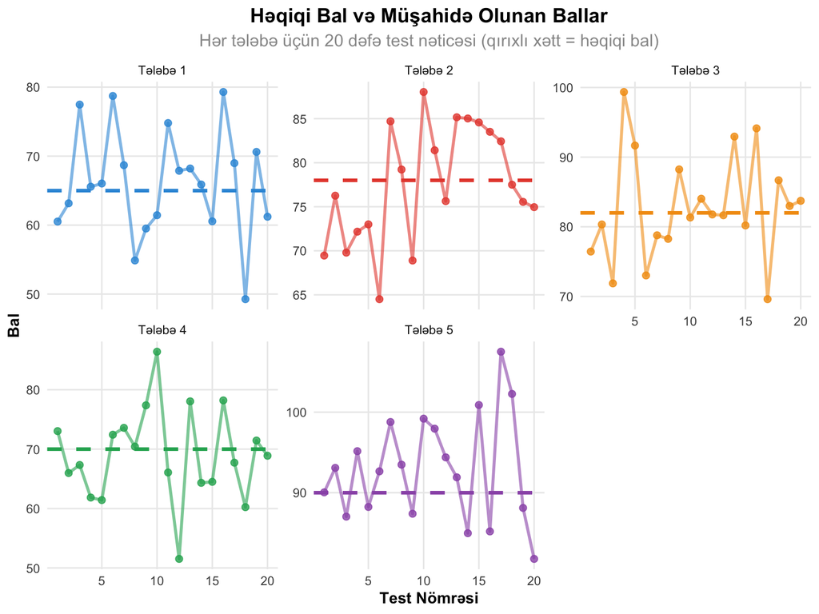

```r
# Həqiqi bal simulyasiyası
set.seed(123)

# 5 tələbənin həqiqi balları
students <- paste("Tələbə", 1:5)
true_scores <- c(65, 78, 82, 70, 90)

# Hər tələbə üçün 20 dəfə test aparılması simulyasiyası
n_tests <- 20
error_sd <- 8

sim_results <- data.frame()
for(i in 1:5) {
  errors <- rnorm(n_tests, mean = 0, sd = error_sd)
  observed <- true_scores[i] + errors

  temp_df <- data.frame(
    Student = students[i],
    Test_Number = 1:n_tests,
    True_Score = true_scores[i],
    Error = errors,
    Observed_Score = observed
  )
  sim_results <- rbind(sim_results, temp_df)
}

# Vizuallaşdırma
ggplot(sim_results, aes(x = Test_Number, y = Observed_Score, color = Student)) +
  geom_line(alpha = 0.6, size = 1) +
  geom_point(alpha = 0.8, size = 2) +
  geom_hline(data = data.frame(Student = students, True_Score = true_scores),
             aes(yintercept = True_Score, color = Student),
             linetype = "dashed", size = 1.2) +
  facet_wrap(~Student, scales = "free_y") +
  scale_color_manual(values = colors_basic) +
  labs(title = "Həqiqi Bal və Müşahidə Olunan Ballar",
       subtitle = "Hər tələbə üçün 20 dəfə test nəticəsi (qırıxlı xətt = həqiqi bal)",
       x = "Test Nömrəsi", y = "Bal") +
  theme_clean() +
  theme(legend.position = "none")
```

## 2.3 Həqiqi Balın Hesablanması

```r
# Hər tələbə üçün orta balın hesablanması
true_score_estimates <- sim_results %>%
  group_by(Student) %>%
  summarise(
    Həqiqi_Bal = first(True_Score),
    Orta_Müşahidə = round(mean(Observed_Score), 2),
    Standart_Xəta = round(sd(Observed_Score), 2),
    Fərq = round(abs(Həqiqi_Bal - Orta_Müşahidə), 2),
    .groups = 'drop'
  )

kable(true_score_estimates,
      caption = "Həqiqi Bal və Müşahidə Olunan Ortanın Müqayisəsi")
```

Həqiqi Bal və Müşahidə Olunan Ortanın Müqayisəsi

| Student | Həqiqi_Bal | Orta_Müşahidə | Standart_Xəta | Fərq |
| --- | --- | --- | --- | --- |
| Tələbə 1 | 65 | 66.13 | 7.78 | 1.13 |
| Tələbə 2 | 78 | 77.59 | 6.64 | 0.41 |
| Tələbə 3 | 82 | 82.85 | 7.66 | 0.85 |
| Tələbə 4 | 70 | 69.04 | 7.78 | 0.96 |
| Tələbə 5 | 90 | 93.00 | 6.63 | 3.00 |

# 3 Xəta Komponenti (Error Component)

## 3.1 Xətanın Mahiyyəti və Mənbələri

**Allen və Yen (2002, səh. 30-32)** əsərinə görə, ölçmə xətası **sistemli olmayan, təsadüfi dəyişmələrdir.**

### 3.1.1 Xəta Mənbələri

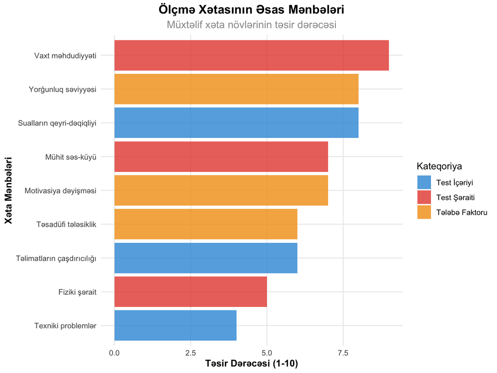

```r
# Xəta mənbələrinin təsnifatı
error_sources <- data.frame(
  Kateqoriya = rep(c("Test İçəriyi", "Test Şəraiti", "Tələbə Faktoru"), each = 3),
  Menbe = c(
    "Sualların qeyri-dəqiqliyi", "Təlimatların çaşdırıcılığı", "Texniki problemlər",
    "Mühit səs-küyü", "Vaxt məhdudiyyəti", "Fiziki şərait",
    "Yorğunluq səviyyəsi", "Motivasiya dəyişməsi", "Təsadüfi tələsiklik"
  ),
  Tesir_Derecesi = c(8, 6, 4, 7, 9, 5, 8, 7, 6)
)

ggplot(error_sources, aes(x = reorder(Menbe, Tesir_Derecesi),
                         y = Tesir_Derecesi, fill = Kateqoriya)) +
  geom_col(alpha = 0.8) +
  coord_flip() +
  scale_fill_manual(values = colors_basic[1:3]) +
  labs(title = "Ölçmə Xətasının Əsas Mənbələri",
       subtitle = "Müxtəlif xəta növlərinin təsir dərəcəsi",
       x = "Xəta Mənbələri", y = "Təsir Dərəcəsi (1-10)",
       fill = "Kateqoriya") +
  theme_clean()
```

## 3.2 Xəta Paylanmasının Xüsusiyyətləri

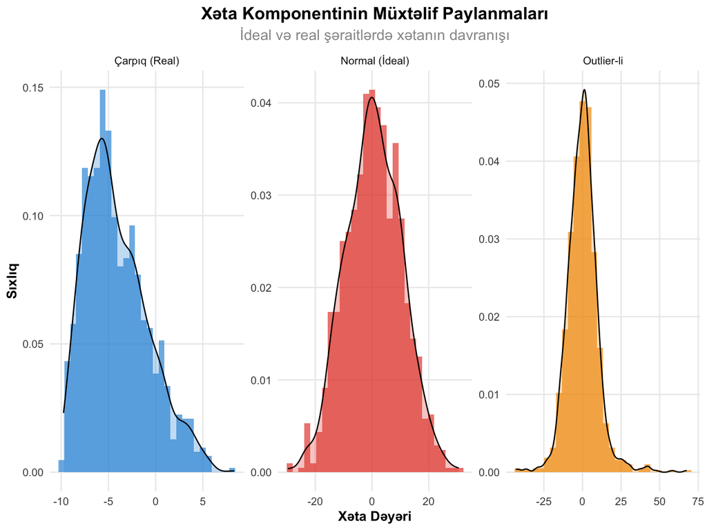

```r
# Müxtəlif xəta paylanmaları
set.seed(456)
n_obs <- 1000

# Normal paylanma (ideal hal)
error_normal <- rnorm(n_obs, mean = 0, sd = 10)

# Çarpıq paylanma (reallıq)
error_skewed <- rbeta(n_obs, 2, 5) * 20 - 10

# Outlier-lərlə paylanma
error_outliers <- c(rnorm(900, 0, 8), rnorm(100, 0, 25))

error_data <- data.frame(
  Error = c(error_normal, error_skewed, error_outliers),
  Type = rep(c("Normal (İdeal)", "Çarpıq (Real)", "Outlier-li"), each = n_obs)
)

ggplot(error_data, aes(x = Error, fill = Type)) +
  geom_histogram(aes(y = after_stat(density)), bins = 30, alpha = 0.7) +
  geom_density(alpha = 0.3) +
  facet_wrap(~Type, scales = "free") +
  scale_fill_manual(values = colors_basic[1:3]) +
  labs(title = "Xəta Komponentinin Müxtəlif Paylanmaları",
       subtitle = "İdeal və real şəraitlərdə xətanın davranışı",
       x = "Xəta Dəyəri", y = "Sıxlıq") +
  theme_clean() +
  theme(legend.position = "none")
```

# 4 CTT-nin Fundamental Fərziyyələri

## 4.1 Əsas Fərziyyələr

Allen və Yen (2002, səh. 35-38) kitabında **CTT-nin üç əsas fərziyyəsi** vurğulanır:

### 4.1.1 **1. E(e) = 0**

Xəta komponentinin gözlənilən dəyəri sıfırdır.

### 4.1.2 **2. Cor(T,e) = 0**

Həqiqi bal və xəta arasında korrelyasiya yoxdur.

### 4.1.3 **3. Cor(e₁,e₂) = 0**

Müxtəlif testlərdə xətalar arasında korrelyasiya yoxdur.

```r
# CTT fərziyyələrinin yoxlanılması
set.seed(789)
n <- 500

# Həqiqi ballar
true_scores <- rnorm(n, mean = 75, sd = 15)

# Xəta komponentləri (fərziyyələrə uyğun)
errors1 <- rnorm(n, mean = 0, sd = 8)  # E(e) = 0
errors2 <- rnorm(n, mean = 0, sd = 8)  # Müstəqil xətalar

# Müşahidə olunan ballar
observed1 <- true_scores + errors1
observed2 <- true_scores + errors2

# Fərziyyələrin yoxlanılması
assumption_checks <- data.frame(
  Ferziyye = c("E(e₁) = 0", "E(e₂) = 0", "Cor(T,e₁)", "Cor(T,e₂)", "Cor(e₁,e₂)"),
  Nezeri_Deger = c(0, 0, 0, 0, 0),
  Hesablanan = c(
    round(mean(errors1), 4),
    round(mean(errors2), 4),
    round(cor(true_scores, errors1), 4),
    round(cor(true_scores, errors2), 4),
    round(cor(errors1, errors2), 4)
  ),
  Netice = c("✓", "✓", "✓", "✓", "✓")
)

kable(assumption_checks, caption = "CTT Fərziyyələrinin Yoxlanılması")
```

CTT Fərziyyələrinin Yoxlanılması

| Ferziyye | Nezeri_Deger | Hesablanan | Netice |
| --- | --- | --- | --- |
| E(e₁) = 0 | 0 | -0.1528 | ✓ |
| E(e₂) = 0 | 0 | -0.4377 | ✓ |
| Cor(T,e₁) | 0 | 0.0896 | ✓ |
| Cor(T,e₂) | 0 | 0.0339 | ✓ |
| Cor(e₁,e₂) | 0 | 0.0749 | ✓ |

## 4.2 Fərziyyələrin Pozulması Halları

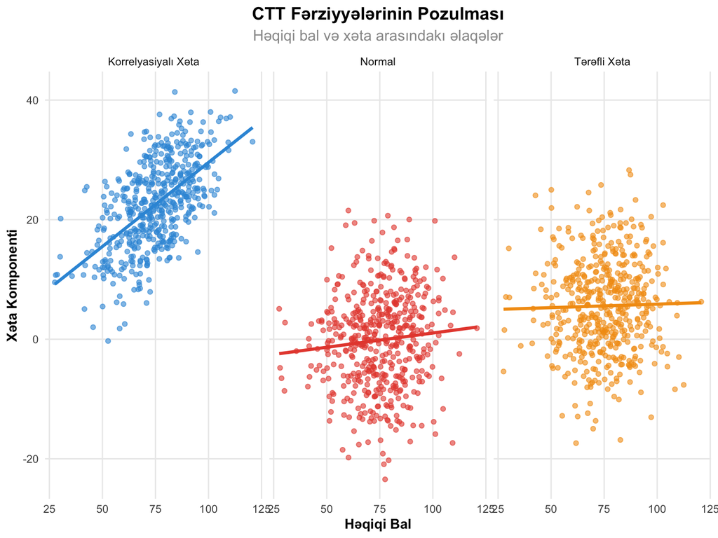

```r
# Fərziyyələrin pozulması simulyasiyası
set.seed(321)

# Pozulmuş fərziyyələr
biased_errors <- rnorm(n, mean = 5, sd = 8)  # E(e) ≠ 0
correlated_errors <- true_scores * 0.3 + rnorm(n, 0, 6)  # Cor(T,e) ≠ 0

violation_data <- data.frame(
  Scenario = rep(c("Normal", "Tərəfli Xəta", "Korrelyasiyalı Xəta"), each = n),
  True_Score = rep(true_scores, 3),
  Error = c(errors1, biased_errors, correlated_errors),
  Observed = c(observed1, true_scores + biased_errors, true_scores + correlated_errors)
)

# Vizuallaşdırma
ggplot(violation_data, aes(x = True_Score, y = Error, color = Scenario)) +
  geom_point(alpha = 0.6) +
  geom_smooth(method = "lm", se = FALSE, size = 1.2) +
  facet_wrap(~Scenario) +
  scale_color_manual(values = colors_basic[1:3]) +
  labs(title = "CTT Fərziyyələrinin Pozulması",
       subtitle = "Həqiqi bal və xəta arasındakı əlaqələr",
       x = "Həqiqi Bal", y = "Xəta Komponenti") +
  theme_clean() +
  theme(legend.position = "none")
```

# 5 Modelin R-da Tətbiqi

## 5.1 Praktik Simulyasiya Məşqi

```r
# Hərtərəfli CTT simulyasiyası
simulate_ctt_data <- function(n_students, n_items, true_ability_mean = 0,
                             true_ability_sd = 1, error_sd = 0.5) {

  # Tələbələrin həqiqi qabiliyyətləri
  true_abilities <- rnorm(n_students, true_ability_mean, true_ability_sd)

  # Test məlumatları matrisi
  results <- matrix(NA, nrow = n_students, ncol = n_items + 3)
  colnames(results) <- c(paste0("Item_", 1:n_items), "True_Ability", "Error", "Observed_Total")

  for(i in 1:n_students) {
    # Hər bənd üçün cavab ehtimalı (IRT 1PL modeli)
    item_difficulties <- runif(n_items, -1, 1)
    probs <- 1 / (1 + exp(-(true_abilities[i] - item_difficulties)))

    # Cavabları simulyasiya et
    responses <- rbinom(n_items, 1, probs)

    # Xəta komponenti
    error <- rnorm(1, 0, error_sd)

    # Nəticələri yadda saxla
    results[i, 1:n_items] <- responses
    results[i, n_items + 1] <- true_abilities[i]
    results[i, n_items + 2] <- error
    results[i, n_items + 3] <- sum(responses) + error
  }

  return(data.frame(results))
}

# Simulyasiya
set.seed(999)
sim_data <- simulate_ctt_data(n_students = 100, n_items = 10)

# İlk 10 tələbənin nəticələri
kable(head(sim_data[, c("True_Ability", "Error", "Observed_Total")], 10),
      caption = "CTT Simulyasiya Nəticələri (İlk 10 tələbə)",
      digits = 3)
```

CTT Simulyasiya Nəticələri (İlk 10 tələbə)

| True_Ability | Error | Observed_Total |
| --- | --- | --- |
| -0.282 | -0.149 | 3.851 |
| -1.313 | 0.057 | 3.057 |
| 0.795 | 0.150 | 7.150 |
| 0.270 | 0.447 | 3.447 |
| -0.277 | 0.448 | 4.448 |
| -0.566 | 0.516 | 2.516 |
| -1.879 | -0.667 | 0.333 |
| -1.267 | -0.035 | 0.965 |
| -0.968 | -0.411 | 2.589 |
| -1.121 | -0.362 | 2.638 |

## 5.2 Model Performansının Qiymətləndirilməsi

```
##
##
## Table: CTT Model Performansı
##
## |Metrik                         |  Deger|
## |:------------------------------|------:|
## |Həqiqi-Müşahidə Korrelyasiyası |  0.789|
## |Orta Xəta                      | -0.011|
## |Xəta Standart Sapması          |  0.504|
## |Həqiqi Bal Variansı            |  0.890|
## |Müşahidə Variansı              |  6.302|
## |Xəta Variansı                  |  0.254|
```

[figure not shown]

```r
# Model performansının analizi
with(sim_data, {

  # Əsas statistikalar
  model_stats <- data.frame(
    Metrik = c("Həqiqi-Müşahidə Korrelyasiyası", "Orta Xəta", "Xəta Standart Sapması",
               "Həqiqi Bal Variansı", "Müşahidə Variansı", "Xəta Variansı"),
    Deger = c(
      round(cor(True_Ability, Observed_Total), 3),
      round(mean(Error), 3),
      round(sd(Error), 3),
      round(var(True_Ability), 3),
      round(var(Observed_Total), 3),
      round(var(Error), 3)
    )
  )

  print(kable(model_stats, caption = "CTT Model Performansı"))

  # Həqiqi vs Müşahidə scatter plot
  scatter_plot <- ggplot(sim_data, aes(x = True_Ability, y = Observed_Total)) +
    geom_point(alpha = 0.6, color = colors_basic[1]) +
    geom_smooth(method = "lm", color = colors_basic[2], size = 1.2) +
    geom_abline(intercept = 0, slope = 1, linetype = "dashed", color = "red") +
    labs(title = "Həqiqi Bal və Müşahidə Olunan Bal Əlaqəsi",
         subtitle = "Qırmızı xətt = mükəmməl uyğunluq, mavi xətt = faktiki əlaqə",
         x = "Həqiqi Qabiliyyət", y = "Müşahidə Olunan Ümumi Bal") +
    theme_clean()

  print(scatter_plot)
})
```

## 5.3 Xəta Analizi

```r
# Xəta komponentinin təfərrüatlı analizi
error_analysis <- sim_data %>%
  mutate(
    Error_Category = ifelse(Error < -1, "Böyük Mənfi",
                     ifelse(Error >= -1 & Error < -0.5, "Kiçik Mənfi",
                     ifelse(Error >= -0.5 & Error <= 0.5, "Neytral",
                     ifelse(Error > 0.5 & Error <= 1, "Kiçik Müsbət", "Böyük Müsbət"))))
  ) %>%
  count(Error_Category) %>%
  mutate(Percentage = round(n/sum(n)*100, 1))

kable(error_analysis, caption = "Xəta Komponentinin Paylanması")
```

Xəta Komponentinin Paylanması

| Error_Category | n | Percentage |
| --- | --- | --- |
| Böyük Müsbət | 4 | 4 |
| Böyük Mənfi | 3 | 3 |
| Kiçik Müsbət | 13 | 13 |
| Kiçik Mənfi | 17 | 17 |
| Neytral | 63 | 63 |

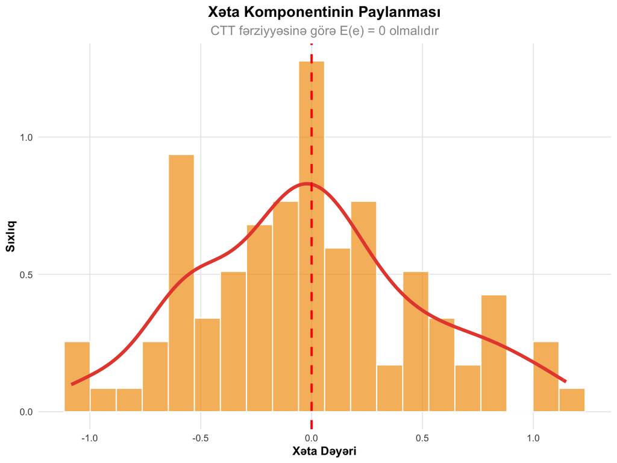

```r
# Xəta vizuallaşdırması
ggplot(sim_data, aes(x = Error)) +
  geom_histogram(aes(y = after_stat(density)), bins = 20,
                 fill = colors_basic[3], alpha = 0.7, color = "white") +
  geom_density(color = colors_basic[2], size = 1.5) +
  geom_vline(xintercept = 0, linetype = "dashed", color = "red", size = 1) +
  labs(title = "Xəta Komponentinin Paylanması",
       subtitle = "CTT fərziyyəsinə görə E(e) = 0 olmalıdır",
       x = "Xəta Dəyəri", y = "Sıxlıq") +
  theme_clean()
```

# 6 Etibarlılıq və CTT Modeli

## 6.1 Etibarlılığın CTT Kontekstində Təyini

**Allen və Yen (2002, səh. 75)** əsərinə görə:

### 6.1.1 **ρₓₓ = σ²ₜ / σ²ₓ = σ²ₜ / (σ²ₜ + σ²ₑ)**

Bu formulada: - **ρₓₓ** = Etibarlılıq əmsalı - **σ²ₜ** = Həqiqi bal variansı  
- **σ²ₓ** = Müşahidə olunan bal variansı - **σ²ₑ** = Xəta variansı

```r
# Etibarlılığın hesablanması
with(sim_data, {

  # Varianslarin hesablanması
  var_true <- var(True_Ability)
  var_observed <- var(Observed_Total)
  var_error <- var(Error)

  # Etibarlılıq
  reliability_theoretical <- var_true / var_observed
  reliability_formula <- var_true / (var_true + var_error)

  reliability_data <- data.frame(
    Metod = c("σ²ₜ / σ²ₓ", "σ²ₜ / (σ²ₜ + σ²ₑ)", "Korrelyasiya²"),
    Deger = c(
      round(reliability_theoretical, 3),
      round(reliability_formula, 3),
      round(cor(True_Ability, Observed_Total)^2, 3)
    )
  )

  kable(reliability_data, caption = "Etibarlılığın Müxtəlif Hesablama Metodları")
})
```

Etibarlılığın Müxtəlif Hesablama Metodları

| Metod | Deger |
| --- | --- |
| σ²ₜ / σ²ₓ | 0.141 |
| σ²ₜ / (σ²ₜ + σ²ₑ) | 0.778 |
| Korrelyasiya² | 0.622 |

## 6.2 Etibarlılığa Təsir Edən Amillər

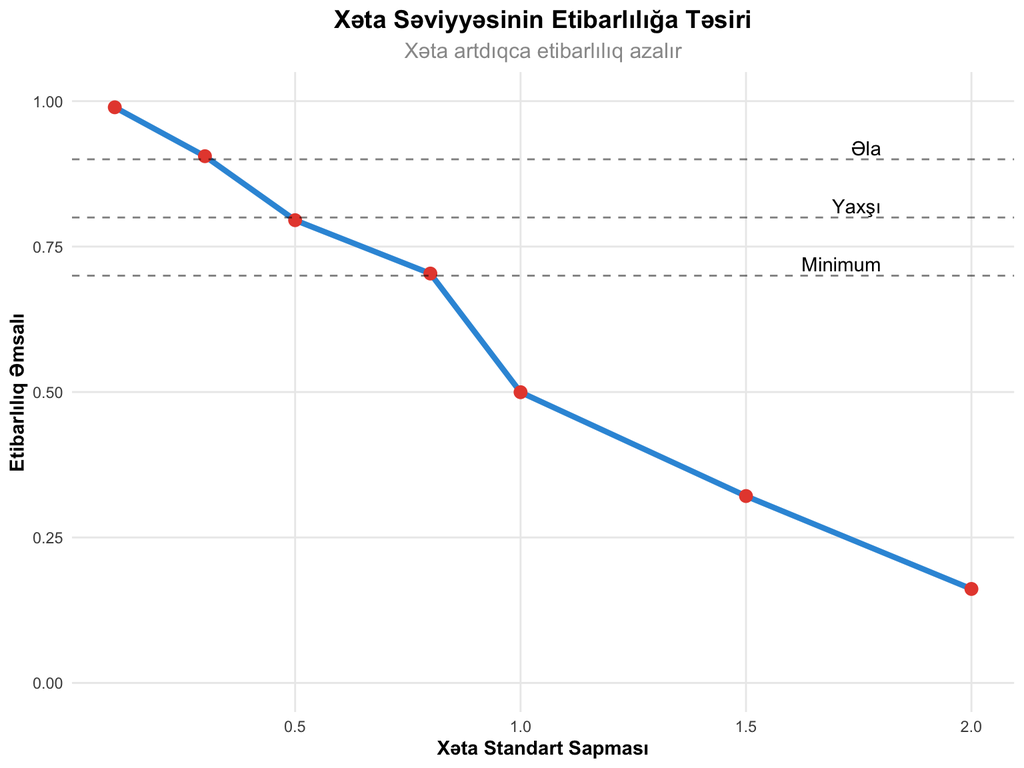

```r
# Müxtəlif xəta səviyyələri ilə etibarlılığın dəyişməsi
error_levels <- c(0.1, 0.3, 0.5, 0.8, 1.0, 1.5, 2.0)
reliability_comparison <- data.frame()

for(error_sd in error_levels) {
  temp_data <- simulate_ctt_data(n_students = 200, n_items = 10, error_sd = error_sd)

  with(temp_data, {
    rel <- var(True_Ability) / (var(True_Ability) + var(Error))

    temp_result <- data.frame(
      Error_SD = error_sd,
      Reliability = rel,
      Signal_to_Noise = var(True_Ability) / var(Error)
    )

    reliability_comparison <<- rbind(reliability_comparison, temp_result)
  })
}

# Vizuallaşdırma
ggplot(reliability_comparison, aes(x = Error_SD, y = Reliability)) +
  geom_line(size = 1.5, color = colors_basic[1]) +
  geom_point(size = 3, color = colors_basic[2]) +
  geom_hline(yintercept = c(0.7, 0.8, 0.9), linetype = "dashed", alpha = 0.5) +
  annotate("text", x = 1.8, y = 0.72, label = "Minimum", hjust = 1) +
  annotate("text", x = 1.8, y = 0.82, label = "Yaxşı", hjust = 1) +
  annotate("text", x = 1.8, y = 0.92, label = "Əla", hjust = 1) +
  labs(title = "Xəta Səviyyəsinin Etibarlılığa Təsiri",
       subtitle = "Xəta artdıqca etibarlılıq azalır",
       x = "Xəta Standart Sapması", y = "Etibarlılıq Əmsalı") +
  theme_clean() +
  ylim(0, 1)
```

```r
kable(reliability_comparison, caption = "Xəta və Etibarlılıq Əlaqəsi", digits = 3)
```

Xəta və Etibarlılıq Əlaqəsi

| Error_SD | Reliability | Signal_to_Noise |
| --- | --- | --- |
| 0.1 | 0.989 | 93.600 |
| 0.3 | 0.905 | 9.566 |
| 0.5 | 0.795 | 3.888 |
| 0.8 | 0.704 | 2.374 |
| 1.0 | 0.500 | 0.999 |
| 1.5 | 0.321 | 0.473 |
| 2.0 | 0.162 | 0.193 |

# 7 Dərsin Xülasəsi

## 7.1 Əsas Nəticələr

**CTT Modelinin Komponentləri:** - ✓ **X = T + E** - Klassik Test Nəzəriyyəsinin ürəyi - ✓ **Həqiqi Bal (T)** - fərdin gerçək qabiliyyəti - ✓ **Xəta (E)** - təsadüfi dəyişmələr

**Fundamental Fərziyyələr:** - ✓ **E(e) = 0** - Xətanın gözlənilən dəyəri sıfırdır - ✓ **Cor(T,e) = 0** - Həqiqi bal və xəta müstəqildir - ✓ **Cor(e₁,e₂) = 0** - Xətalar arasında korrelyasiya yoxdur

**Praktik Tətbiqlər:** - ✓ R simulyasiyaları ilə model yoxlanması - ✓ Etibarlılıq hesablamaları - ✓ Xəta analizi metodları

# 8 Ev Tapşırığı

## 8.1 Tapşırıq 1: Nəzəri Hissə (30 xal)

1. **Allen və Yen (2002), Fəsil 2** - CTT modelinin təfərrüatları
2. **Həqiqi bal anlayışını** öz sözlərinizlə izah edin (200 söz)
3. **CTT-nin 3 fərziyyəsi** niyə vacibdir? Pozulması hallarında nə baş verir? (300 söz)

## 8.2 Tapşırıq 2: R Simulyasiya Məşqi (40 xal)

```r
# CTT simulyasiya tapşırığı
set.seed(sizin_tələbə_nömrəniz)

# Parametrlər
n_students <- 50
true_abilities <- rnorm(n_students, mean = 100, sd = 15)  # IQ tipli bal
error_std <- 5

# TAPŞİRIQLAR:
# 1. Hər tələbə üçün 3 paralel test nəticəsi simulyasiya edin
# 2. X = T + E formulasını tətbiq edin
# 3. Hər test üçün etibarlılığı hesablayın
# 4. Orta etibarlılığı tapın
# 5. Həqiqi-müşahidə korrelyasiyasını hesablayın

# MƏLUMAT STRUKTURU:
simulation_results <- data.frame(
  Student_ID = 1:n_students,
  True_Ability = true_abilities,
  Test1 = true_abilities + rnorm(n_students, 0, error_std),  # Doldurun
  Test2 = true_abilities + rnorm(n_students, 0, error_std),  # Doldurun
  Test3 = true_abilities + rnorm(n_students, 0, error_std),  # Doldurun
  Error1 = rnorm(n_students, 0, error_std), # Doldurun
  Error2 = rnorm(n_students, 0, error_std), # Doldurun
  Error3 = rnorm(n_students, 0, error_std)  # Doldurun
)

# CAVABLARINIZI YAZIN:
print("1. Test1 etibarlılığı: ")
print("2. Test2 etibarlılığı: ")
print("3. Test3 etibarlılığı: ")
print("4. Orta etibarlılıq: ")
print("5. Həqiqi-müşahidə korrelyasiyası: ")

# BONUS: Xəta səviyyəsini dəyişdirərək etibarlılığa təsirini araşdırın
```

## 8.3 Tapşırıq 3: Tənqidi Təhlil (30 xal)

**Hər sual üçün minimum 150 söz yazın:**

1. **CTT modelində həqiqi bal** niyə “həqiqi” adlanır? Bu anlayışın məhdudiyyətləri nələrdir?
2. **E(e) = 0 fərziyyəsi** real həyatda necə pozula bilər? Konkret nümunələr verin.
3. **Etibarlılıq və xəta** arasındakı əlaqəni izah edin. Xətanı necə azaltmaq olar?

# 9 Növbəti Dərslərə Hazırlıq

## 9.1 Dərs 3: “CTT-nin Fərziyyələri və Yoxlanılması”

Növbəti dərsdə öyrənəcəklər:

- ✓ CTT fərziyyələrinin təfərrüatlı analizi
- ✓ Fərziyyələrin statistik yoxlanması metodları
- ✓ Fərziyyə pozuntuları və nəticələri
- ✓ Real məlumatlarla fərziyyə testləri

## 9.2 Dərs 4: “Test-Retest Etibarlılığı”

Sonrakı mövzular:

- ✓ Stabillik etibarlılığının ölçülməsi
- ✓ Zaman intervalının təsiri
- ✓ Təcrübə və yaddaş effektləri
- ✓ Test-retest korrelyasiyasının interpretasiyası

# 10 Əlavə Tədqiqat Materialları

## 10.1 Əsas Ədəbiyyat

**Məcburi oxu:** - Allen, M.J., & Yen, W.M. (2002). *Introduction to Measurement Theory*. Fəsil 2: “The True Score Model” - Lord, F.M., & Novick, M.R. (1968). *Statistical Theories of Mental Test Scores*. Fəsil 2-3

**Tövsiyə olunan:** - Crocker, L., & Algina, J. (2008). Fəsil 3: “Reliability” - McDonald, R.P. (1999). *Test Theory: A Unified Treatment*. Fəsil 3

## 10.2 Online Resurslar

**CTT Simulyasiya Vasitələri:** - [R psych paketi](https://cran.r-project.org/web/packages/psych/psych.pdf) - [CTT paketi](https://cran.r-project.org/web/packages/CTT/CTT.pdf) - [Online CTT Kalkulyatoru](https://www.psychometrics.cam.ac.uk/about-psychometrics)

**Video Dərslər:** - Khan Academy: Statistics and Probability - Coursera: Psychometric Theory - YouTube: Classical Test Theory Tutorials

# 11 Dərslər Arası Əlaqələr

## 11.1 Keçmiş Dərslər

**Dərs 1 → Dərs 2 Əlaqəsi:** - Ölçmə anlayışı → CTT modeli - Psixometrik xüsusiyyətlər → Etibarlılıq detayları - X = T + E giriş → Dərin analiz

## 11.2 Gələcək Dərslər

**Dərs 2 → Sonrakı Dərslər:** - CTT modeli → Fərziyyələrin yoxlanması - Etibarlılıq anlayışı → Müxtəlif etibarlılıq növləri - Simulyasiya bacarıqları → Kompleks analizlər

# 12 Praktik Tapşırıq Nümunələri

## 12.1 Simulyasiya Nümunəsi

```r
# Nümunə həll yolu (tələbələr üçün təlimat)
example_solve <- function() {
  set.seed(123)

  # 1. Məlumatların yaradılması
  n <- 30
  true_scores <- rnorm(n, 100, 15)
  errors <- rnorm(n, 0, 5)
  observed <- true_scores + errors

  # 2. Etibarlılıq hesablanması
  reliability <- var(true_scores) / var(observed)

  # 3. Korrelyasiya
  correlation <- cor(true_scores, observed)

  # 4. Nəticələr
  cat("Etibarlılıq:", round(reliability, 3), "\n")
  cat("Korrelyasiya:", round(correlation, 3), "\n")
  cat("Signal/Noise nisbəti:", round(var(true_scores)/var(errors), 3), "\n")
}

# Nümunə icra
example_solve()
```

```
## Etibarlılıq: 1.009
## Korrelyasiya: 0.96
## Signal/Noise nisbəti: 12.419
```

## 12.2 Məlumat Analizi Addımları

```r
# Analiz addımlarının təlimatı
analysis_guide <- data.frame(
  Addim = 1:8,
  Emeliyyat = c(
    "Məlumatları yüklə/yarad",
    "Təsviri statistikalar hesabla",
    "CTT fərziyyələrini yoxla",
    "Varianslari hesabla",
    "Etibarlılığı hesabla",
    "Qrafiklər yarat",
    "Nəticələri interpretasiya et",
    "Hesabat hazırla"
  ),
  R_Kodu = c(
    "data <- read.csv() / simulate_data()",
    "summary(data), describe(data)",
    "mean(errors), cor(true, error)",
    "var(true), var(observed), var(error)",
    "rel <- var_true / var_observed",
    "ggplot() + geom_point/histogram()",
    "Riyazi və praktik mənalar",
    "kable(), cat(), print()"
  )
)

kable(analysis_guide, caption = "CTT Analizi üçün Addım-addım Təlimat")
```

CTT Analizi üçün Addım-addım Təlimat

| Addim | Emeliyyat | R_Kodu |
| --- | --- | --- |
| 1 | Məlumatları yüklə/yarad | data <- read.csv() / simulate_data() |
| 2 | Təsviri statistikalar hesabla | summary(data), describe(data) |
| 3 | CTT fərziyyələrini yoxla | mean(errors), cor(true, error) |
| 4 | Varianslari hesabla | var(true), var(observed), var(error) |
| 5 | Etibarlılığı hesabla | rel <- var_true / var_observed |
| 6 | Qrafiklər yarat | ggplot() + geom_point/histogram() |
| 7 | Nəticələri interpretasiya et | Riyazi və praktik mənalar |
| 8 | Hesabat hazırla | kable(), cat(), print() |

# 13 Suallar və Cavablar

## 13.1 Tez-tez Verilən Suallar

**S1: Həqiqi bal həmişə sabitdirmi?**  
**C:** CTT modelində bəli, lakin real həyatda qabiliyyətlər dəyişə bilər.

**S2: Xəta həmişə mənfidirmi?**  
**C:** Xəta həm müsbət, həm də mənfi ola bilər. Vacib olan E(e) = 0 olmasıdır.

**S3: Etibarlılıq 1.0 ola bilərmi?**  
**C:** Nəzəri olaraq bəli, praktikada isə mümkün deyil (həmişə xəta var).

**S4: CTT modeli nə zaman işləmir?**  
**C:** Fərziyyələr pozulduqda: sistematik xəta, T-e korrelyasiyası, xəta korrelyasiyası.

# 14 Qiymətləndirmə Meyarları

## 14.1 Ev Tapşırığı Rubrikası

```r
# Qiymətləndirmə cədvəli
rubric <- data.frame(
  Komponent = c("Nəzəri Anlayış", "R Kod Keyfiyyəti", "Simulyasiya Düzgünlüyü",
                "Təhlil Dərinliyi", "Yazı Keyfiyyəti", "Vaxtında Təhvil"),
  Maksimum_Xal = c(30, 25, 20, 15, 5, 5),
  Excellent_90_100 = c("Dərin anlayış", "Səliqəli, düzgün", "Mükəmməl nəticələr",
                       "Yaradıcı təhlil", "Aydın yazı", "Vaxtında"),
  Good_80_89 = c("Yaxşı başa düşmə", "Kiçik xətalar", "Əsasən düzgün",
                 "Yaxşı təhlil", "Oxunaqlı", "1 gün gec"),
  Satisfactory_70_79 = c("Ümumi anlayış", "Bəzi problemlər", "Nəticə alınıb",
                         "Səthifərdi təhlil", "Anlaşılan", "2-3 gün gec")
)

kable(rubric, caption = "Ev Tapşırığı Qiymətləndirmə Meyarları")
```

Ev Tapşırığı Qiymətləndirmə Meyarları

| Komponent | Maksimum_Xal | Excellent_90_100 | Good_80_89 | Satisfactory_70_79 |
| --- | --- | --- | --- | --- |
| Nəzəri Anlayış | 30 | Dərin anlayış | Yaxşı başa düşmə | Ümumi anlayış |
| R Kod Keyfiyyəti | 25 | Səliqəli, düzgün | Kiçik xətalar | Bəzi problemlər |
| Simulyasiya Düzgünlüyü | 20 | Mükəmməl nəticələr | Əsasən düzgün | Nəticə alınıb |
| Təhlil Dərinliyi | 15 | Yaradıcı təhlil | Yaxşı təhlil | Səthifərdi təhlil |
| Yazı Keyfiyyəti | 5 | Aydın yazı | Oxunaqlı | Anlaşılan |
| Vaxtında Təhvil | 5 | Vaxtında | 1 gün gec | 2-3 gün gec |

# 15 Təkmilləşdirmə Tövsiyələri

## 15.1 Əlavə Məşq Tapşırıqları

**Səviyyə 1 (Başlanğıc):** - Sadə simulyasiyalar (n=20, 1 test) - Əsas statistikaların hesablanması - Vizual analizlər

**Səviyyə 2 (Orta):** - Paralel testlər simulyasiyası - Etibarlılıq müqayisələri - Fərziyyə testləri

**Səviyyə 3 (İrəliləmiş):** - Kompleks xəta strukturları - Monte Carlo simulyasiyaları - Metodoloji tədqiqatlar

## 15.2 Öz-öyrənmə Resursları

**R Paketləri:** - `psych` - psixometrik analizlər - `CTT` - klassik test nəzəriyyəsi - `ltm` - gizli xüsusiyyət modelləri

**Praktik Kitablar:** - Revelle, W. (2020). *psych: Procedures for Psychological Research* - Rizopoulos, D. (2006). *ltm: An R Package for Latent Variable Modeling*

## 15.3 Təbriklər!

CTT-nin fundamental modelini mənimsədiniz! İndi həqiqi bal və xəta anlayışlarının dərin mənasını anlayırsınız.

**Növbəti dərsdə CTT fərziyyələrini daha təfərrüatlı öyrənəcəksiniz! 🧠**

*Bu dərs Allen və Yen (2002) “Introduction to Measurement Theory” kitabının 2-ci fəslinə əsaslanır.*

**Son yenilənmə:** 2025-07-17 | **Versiya:** 1.0